# Cyclist data Case study

Sai Singireddy

2024-02-27

## **Documentation**

### **Business task**:

The business task involves me being a data analyst for a bike rental company and the problem mainly focusses on converting casual riders to members which could potentially lead to company growth.

Now i’m going to explain the way I addressed this problem from scatch and share my veiws and recommendations to acheive this task.

### **Gathering the data:**

Having obtained the dataset through Coursera, I utilized Python’s Pandas and OS libraries to amalgamate the data of the 12 months from **April 2020 - March 2021**, resulting in a comprehensive dataset of 3.4 million records. Recognizing Python’s limitations in handling such voluminous data and Excel’s inability to load the entire dataset, I transitioned to R programming. This shift allows for more efficient processing and analysis of the extensive dataset, facilitating a clearer and more streamlined workflow.

### **Getting started…**

First I loaded all the essential packages that i’m going to need

```r
library("dplyr")
library("skimr")
library("tidyverse")
```

```r
library("ggplot2")
library("data.table")
library("janitor")
```

Now I loaded my dataset that i’m going to work with in a variable cyclist_data and converted the data frame to enhanced version of dataframe called **data table** as this is more efficient and used for quick manipulation.

```r
cyclist_data <- read.csv("C:\\Users\\acer\\Desktop\\case study1\\combined_data.csv")
cyclist_data <- data.table(cyclist_data)
```

Generating summary statistics and a basic understanding on the data using **Summary()** and also using **skim()** from **skimr** package which is a powerful tool for generating summary statistics and exploring the structure of your dataset.:

```r
summary(cyclist_data)
```

```
##    ride_id          rideable_type       started_at          ended_at
##  Length:3489748     Length:3489748     Length:3489748     Length:3489748
##  Class :character   Class :character   Class :character   Class :character
##  Mode  :character   Mode  :character   Mode  :character   Mode  :character
##
##
##
##
##  start_station_name start_station_id   end_station_name   end_station_id
##  Length:3489748     Length:3489748     Length:3489748     Length:3489748
##  Class :character   Class :character   Class :character   Class :character
##  Mode  :character   Mode  :character   Mode  :character   Mode  :character
##
##
##
##
##    start_lat       start_lng         end_lat         end_lng
##  Min.   :41.64   Min.   :-87.87   Min.   :41.54   Min.   :-88.07
##  1st Qu.:41.88   1st Qu.:-87.66   1st Qu.:41.88   1st Qu.:-87.66
##  Median :41.90   Median :-87.64   Median :41.90   Median :-87.64
##  Mean   :41.90   Mean   :-87.64   Mean   :41.90   Mean   :-87.64
##  3rd Qu.:41.93   3rd Qu.:-87.63   3rd Qu.:41.93   3rd Qu.:-87.63
##  Max.   :42.08   Max.   :-87.52   Max.   :42.16   Max.   :-87.44
##                                   NA's   :4738    NA's   :4738
##  member_casual
##  Length:3489748
##  Class :character
##  Mode  :character
##
##
##
##
```

```r
skim(cyclist_data)
```

Data summary

| Name | cyclist_data |
| --- | --- |
| Number of rows | 3489748 |
| Number of columns | 13 |
| Key | NULL |
| _______________________ |  |
| Column type frequency: |  |
| character | 9 |
| numeric | 4 |
| ________________________ |  |
| Group variables | None |

**Variable type: character**

| skim_variable | n_missing | complete_rate | min | max | empty | n_unique | whitespace |
| --- | --- | --- | --- | --- | --- | --- | --- |
| ride_id | 0 | 1 | 16 | 16 | 0 | 3489539 | 0 |
| rideable_type | 0 | 1 | 11 | 13 | 0 | 3 | 0 |
| started_at | 0 | 1 | 19 | 19 | 0 | 3040228 | 0 |
| ended_at | 0 | 1 | 19 | 19 | 0 | 3027775 | 0 |
| start_station_name | 0 | 1 | 0 | 53 | 122175 | 709 | 0 |
| start_station_id | 0 | 1 | 0 | 35 | 122801 | 1344 | 0 |
| end_station_name | 0 | 1 | 0 | 53 | 143242 | 707 | 0 |
| end_station_id | 0 | 1 | 0 | 35 | 143703 | 1345 | 0 |
| member_casual | 0 | 1 | 6 | 6 | 0 | 2 | 0 |

**Variable type: numeric**

| skim_variable | n_missing | complete_rate | mean | sd | p0 | p25 | p50 | p75 | p100 | hist |
| --- | --- | --- | --- | --- | --- | --- | --- | --- | --- | --- |
| start_lat | 0 | 1 | 41.90 | 0.04 | 41.64 | 41.88 | 41.90 | 41.93 | 42.08 | ▁▁▇▇▁ |
| start_lng | 0 | 1 | -87.64 | 0.03 | -87.87 | -87.66 | -87.64 | -87.63 | -87.52 | ▁▁▂▇▁ |
| end_lat | 4738 | 1 | 41.90 | 0.04 | 41.54 | 41.88 | 41.90 | 41.93 | 42.16 | ▁▁▇▅▁ |
| end_lng | 4738 | 1 | -87.65 | 0.03 | -88.07 | -87.66 | -87.64 | -87.63 | -87.44 | ▁▁▁▇▁ |

### **Data Wrangling**

From the summary statistics the things i found i need to deal with are

- Missing values
- Inconsistent column names
- Duplicated Ride_id’s

```r
cyclist_data <- na.omit(cyclist_data)
cyclist_data <- cyclist_data[!duplicated(cyclist_data$ride_id)]
clean_names(cyclist_data)
```

```
##                   ride_id rideable_type          started_at            ended_at
##                    <char>        <char>              <char>              <char>
##       1: A847FADBBC638E45   docked_bike 2020-04-26 17:45:14 2020-04-26 18:12:03
##       2: 5405B80E996FF60D   docked_bike 2020-04-17 17:08:54 2020-04-17 17:17:03
##       3: 5DD24A79A4E006F4   docked_bike 2020-04-01 17:54:13 2020-04-01 18:08:36
##       4: 2A59BBDF5CDBA725   docked_bike 2020-04-07 12:50:19 2020-04-07 13:02:31
##       5: 27AD306C119C6158   docked_bike 2020-04-18 10:22:59 2020-04-18 11:15:54
##      ---
## 3484798: 9397BDD14798A1BA   docked_bike 2021-03-20 14:58:56 2021-03-20 17:22:47
## 3484799: BBBEB8D51AAD40DA  classic_bike 2021-03-02 11:35:10 2021-03-02 11:43:37
## 3484800: 637FF754DA0BD9E1  classic_bike 2021-03-09 11:07:36 2021-03-09 11:49:11
## 3484801: F8F43A0B978A7A35  classic_bike 2021-03-01 18:11:57 2021-03-01 18:18:37
## 3484802: 3AE64EA5BF43CF72 electric_bike 2021-03-26 17:58:14 2021-03-26 18:06:43
##                    start_station_name start_station_id
##                                <char>           <char>
```

[output cut: 37 more lines]

**Clean names()** is a function in **janitor** package that ensures all the column names to be formatted consistently.

### **Other manipulations**

- I converted the available datetime series to posixct class as it’s quite useful for analysis of datetime data types.
- Also filtered dataset for rows containing start time after the end time.
- Generated the days associated with the starting day and ending day using **weekdays()** function from lubridate package.
- Generated Duration column in minutes using **difftime()** function.
- Also added month column for the starting date.
- removed the columns start_station_id and end_sation_id.

```r
cyclist_data$started_at <-as.POSIXct(cyclist_data$started_at,format="%Y-%m-%d %H:%M:%S")
cyclist_data$ended_at <- as.POSIXct(cyclist_data$ended_at,format="%Y-%m-%d %H:%M:%S")
cyclist_data <- subset(cyclist_data,ended_at>started_at)
########## adding weekdays wrt starting and ending date
cyclist_data <- cyclist_data %>%
  mutate(starting_day=weekdays(cyclist_data$started_at),endidng_day=weekdays(cyclist_data$ended_at))
cyclist_data <- cyclist_data %>%
  mutate(duration_in_min=as.numeric(difftime(ended_at,started_at,units="mins")))
cyclist_data <- cyclist_data %>%
  mutate(month=format(started_at,"%B"))
cyclist_data <- cyclist_data %>%
  select(-c(start_station_id,end_station_id))
```

Now i rechecked the summary statistics for the cleaned and transformed data.

```r
summary(cyclist_data)
```

```
##    ride_id          rideable_type        started_at
##  Length:3474133     Length:3474133     Min.   :2020-04-01 00:00:30.0
##  Class :character   Class :character   1st Qu.:2020-07-14 18:49:22.0
##  Mode  :character   Mode  :character   Median :2020-08-29 14:41:51.0
##                                        Mean   :2020-09-10 01:54:20.4
##                                        3rd Qu.:2020-10-20 21:28:59.0
##                                        Max.   :2021-03-31 23:59:08.0
##     ended_at                      start_station_name end_station_name
##  Min.   :2020-04-01 00:10:45.00   Length:3474133     Length:3474133
##  1st Qu.:2020-07-14 19:21:01.00   Class :character   Class :character
##  Median :2020-08-29 15:13:04.00   Mode  :character   Mode  :character
##  Mean   :2020-09-10 02:21:50.80
##  3rd Qu.:2020-10-20 21:44:42.00
##  Max.   :2021-04-06 11:00:11.00
##    start_lat       start_lng         end_lat         end_lng
##  Min.   :41.64   Min.   :-87.87   Min.   :41.54   Min.   :-88.07
##  1st Qu.:41.88   1st Qu.:-87.66   1st Qu.:41.88   1st Qu.:-87.66
##  Median :41.90   Median :-87.64   Median :41.90   Median :-87.64
##  Mean   :41.90   Mean   :-87.64   Mean   :41.90   Mean   :-87.65
##  3rd Qu.:41.93   3rd Qu.:-87.63   3rd Qu.:41.93   3rd Qu.:-87.63
##  Max.   :42.08   Max.   :-87.52   Max.   :42.16   Max.   :-87.44
##  member_casual      starting_day       endidng_day        duration_in_min
##  Length:3474133     Length:3474133     Length:3474133     Min.   :    0.02
##  Class :character   Class :character   Class :character   1st Qu.:    7.93
##  Mode  :character   Mode  :character   Mode  :character   Median :   14.55
##                                                           Mean   :   27.51
##                                                           3rd Qu.:   26.63
##                                                           Max.   :58720.03
##     month
##  Length:3474133
##  Class :character
##  Mode  :character
##
##
##
```

```r
skim(cyclist_data)
```

Data summary

| Name | cyclist_data |
| --- | --- |
| Number of rows | 3474133 |
| Number of columns | 15 |
| Key | NULL |
| _______________________ |  |
| Column type frequency: |  |
| character | 8 |
| numeric | 5 |
| POSIXct | 2 |
| ________________________ |  |
| Group variables | None |

**Variable type: character**

| skim_variable | n_missing | complete_rate | min | max | empty | n_unique | whitespace |
| --- | --- | --- | --- | --- | --- | --- | --- |
| ride_id | 0 | 1 | 16 | 16 | 0 | 3474133 | 0 |
| rideable_type | 0 | 1 | 11 | 13 | 0 | 3 | 0 |
| start_station_name | 0 | 1 | 0 | 53 | 122126 | 709 | 0 |
| end_station_name | 0 | 1 | 0 | 53 | 138384 | 707 | 0 |
| member_casual | 0 | 1 | 6 | 6 | 0 | 2 | 0 |
| starting_day | 0 | 1 | 6 | 9 | 0 | 7 | 0 |
| endidng_day | 0 | 1 | 6 | 9 | 0 | 7 | 0 |
| month | 0 | 1 | 3 | 9 | 0 | 12 | 0 |

**Variable type: numeric**

| skim_variable | n_missing | complete_rate | mean | sd | p0 | p25 | p50 | p75 | p100 | hist |
| --- | --- | --- | --- | --- | --- | --- | --- | --- | --- | --- |
| start_lat | 0 | 1 | 41.90 | 0.04 | 41.64 | 41.88 | 41.90 | 41.93 | 42.08 | ▁▁▇▇▁ |
| start_lng | 0 | 1 | -87.64 | 0.03 | -87.87 | -87.66 | -87.64 | -87.63 | -87.52 | ▁▁▂▇▁ |
| end_lat | 0 | 1 | 41.90 | 0.04 | 41.54 | 41.88 | 41.90 | 41.93 | 42.16 | ▁▁▇▅▁ |
| end_lng | 0 | 1 | -87.65 | 0.03 | -88.07 | -87.66 | -87.64 | -87.63 | -87.44 | ▁▁▁▇▁ |
| duration_in_min | 0 | 1 | 27.51 | 251.98 | 0.02 | 7.93 | 14.55 | 26.63 | 58720.03 | ▇▁▁▁▁ |

**Variable type: POSIXct**

| skim_variable | n_missing | complete_rate | min | max | median | n_unique |
| --- | --- | --- | --- | --- | --- | --- |
| started_at | 0 | 1 | 2020-04-01 00:00:30 | 2021-03-31 23:59:08 | 2020-08-29 14:41:51 | 3031568 |
| ended_at | 0 | 1 | 2020-04-01 00:10:45 | 2021-04-06 11:00:11 | 2020-08-29 15:13:04 | 3016751 |

After checking the summary statistics i found there is something wrong with the duration column as the quartiles 1,3 and median seems to be normal but the max duration is way off the charts.So i plotted a simple box plot to checkout the outliers.

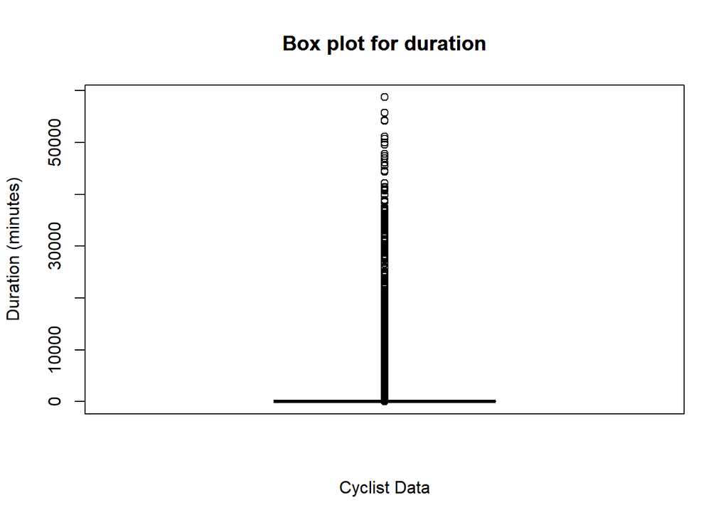

```r
boxplot(cyclist_data$duration_in_min, main = "Box plot for duration", col = "lightblue", border = "black")
title(main = "Box plot for duration")
xlabel <- "Cyclist Data"
ylabel <- "Duration (minutes)"
title(xlab = xlabel, ylab = ylabel)
```

Now it’s clear that i need to deal with the outliers here. There is no specific idea given about how much time can person rent a bike. As the mean is around 30 minutes and the company gives bikes on a daily basis i’m considering a person could rent for maximum 10 hours(600 minutes) and minimum could be 3 minutes (< 3 min is not even a ride in my opinion).First i need to check how many records are with this error.

```r
dim(cyclist_data[cyclist_data$duration_in_min<3])
```

```
## [1] 153744     15
```

```r
dim(cyclist_data[cyclist_data$duration_in_min>600])
```

```
## [1] 6090   15
```

The ride with less than 3 minute duration may seem normal in some cases as biker may have some other work to deal with.But the duration more than 10 hours is definitely not normal, and also the max duration: 40 days is just not right.This could be due to improper returning of bikes or long duration rentals.So instead of removing these outliers i thought of using them for other analysis, so i saved them.And i removed them from original dataset that i’ve been working with.

```r
duration_outlier_data <- cyclist_data %>%
  filter(duration_in_min >600)
cyclist_data <- cyclist_data %>%
  filter(duration_in_min>=3 & duration_in_min <=600)
```

I also noticed that there missing values in start_station and end_station although i omitted the rows with null values.This is because the field is not null but maybe it contains character like ’ ’ this. I thought i will deal with this later because there are nearly 1 lakh rows like this and removing them might not be the most useful thing i could do right now.

### **Moving to visualizing**

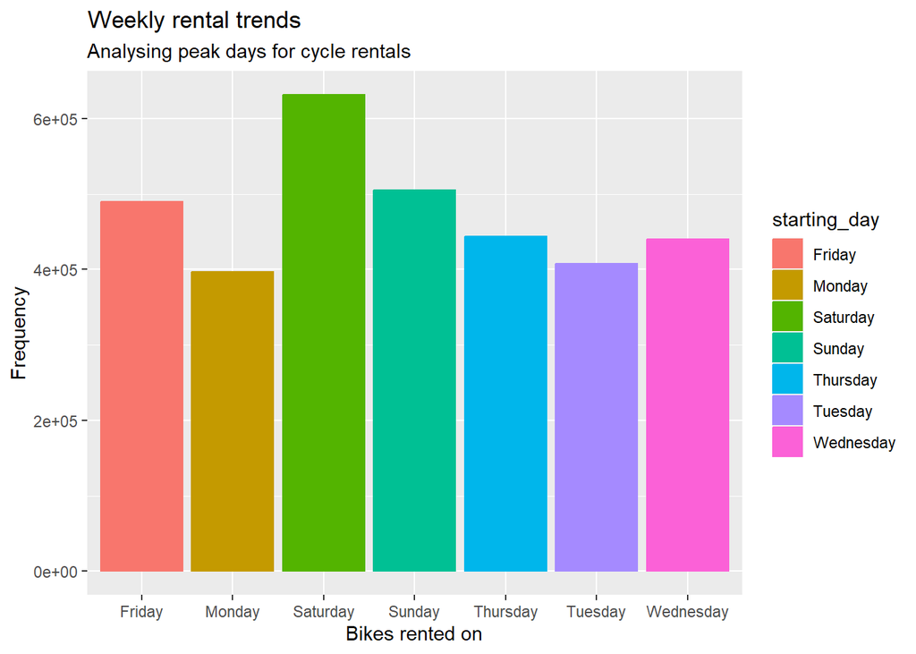

```r
ggplot(data = cyclist_data)+
  geom_bar(mapping = aes(x=starting_day,color=starting_day,fill=starting_day))+
  labs(title = "Weekly rental trends",subtitle = "Analysing peak days for cycle rentals",x="Bikes rented on",y="Frequency")
```

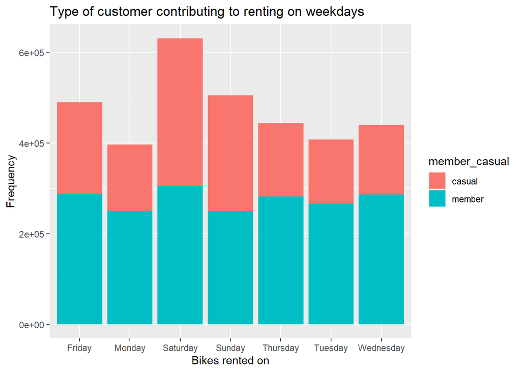

```r
ggplot(data=cyclist_data)+
  geom_bar(mapping=aes(x=starting_day,fill=member_casual))+
  labs(title = "Type of customer contributing to renting on weekdays",x="Bikes rented on",y="Frequency")
```

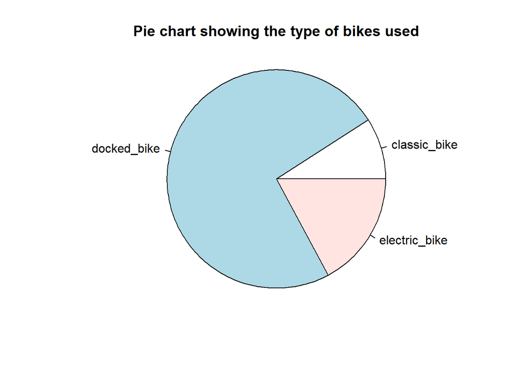

```r
pie(radius = 1,(rideable_count <- table(cyclist_data$rideable_type)),main = "Pie chart showing the type of bikes used")
```

- From this pie chart we can confirm that **docked bikes** are the showstopper and customer favorite type of bike category.

```r
ggplot(data=cyclist_data)+
  geom_bar(mapping=aes(x=starting_day,fill=member_casual))+facet_wrap(~month)+
  labs(title = "Monthly trends of bike usage",x="Weekday",y="frequency")

ggplot(data=cyclist_data)+
  geom_bar(mapping=aes(x=starting_day,fill=rideable_type))+facet_wrap(~month)+
  labs(title = "Monthly trends of bike usage based on bike type",x="Weekday",y="frequency")
```

These both codes generate the following plots:

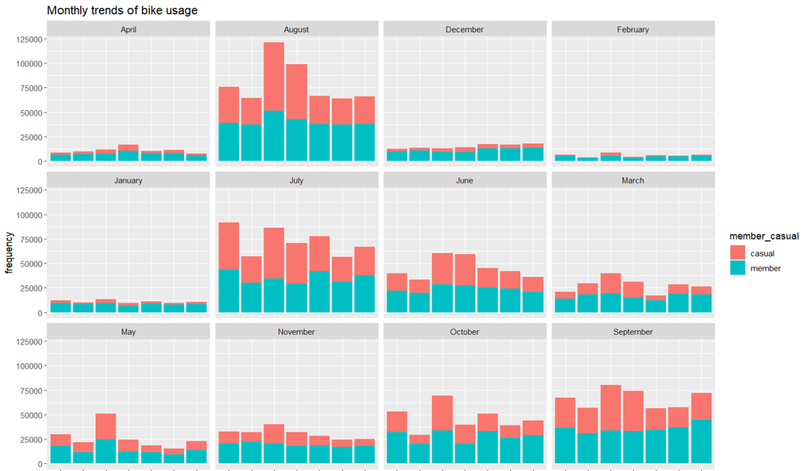

- The peek months recorded are july to september where the casual riders and members were so actively contributing to the rentals. Maybe the reason is that these are the times of summer vacation.

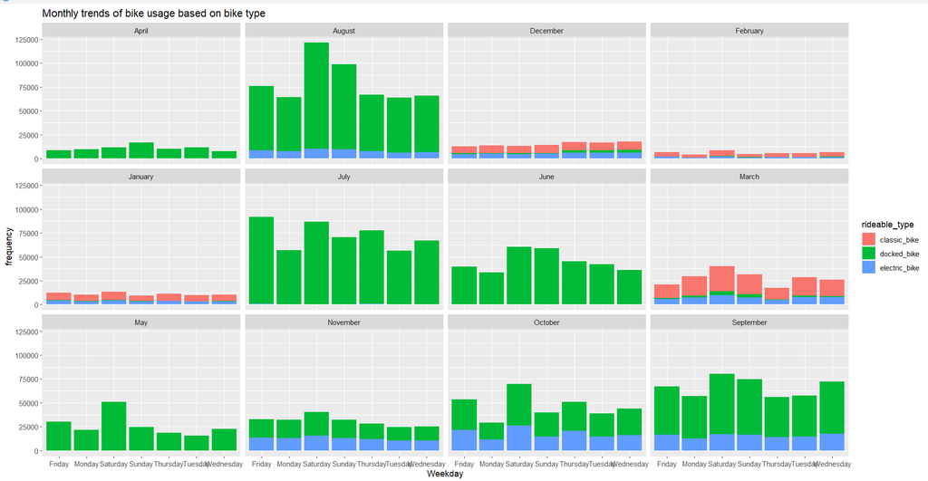

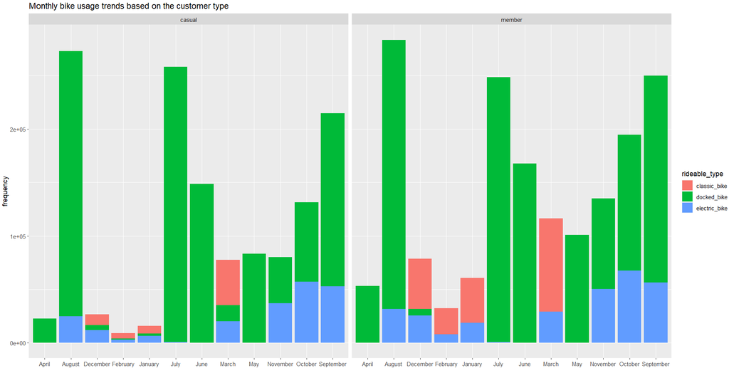

```r
ggplot(data=cyclist_data)+
  geom_bar(mapping=aes(x=month,fill=rideable_type))+facet_wrap(~member_casual)+
  labs(title="Monthly bike usage trends based on the customer type",x='',y="frequency")
```

- Sometimes scale of the graph can hide some potential insights, so i plotted this graph just to make sure that i did not overlook the magnitude of rise of rentals in the peak months. This shows that there was a huge demand of bikes in the peak months(july - september) from both casual riders and members.

I even utilized Tableau for vizualising the regions where there are significant volumes of bike rentals.I used the latitude and longitude of starting points to create a scatterplotplot on map and compared this with the map of chicago from google maps.

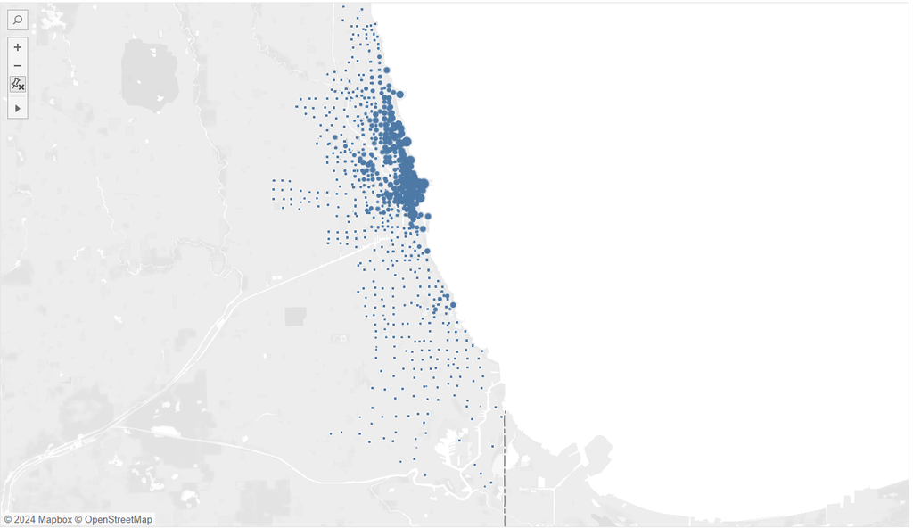

[figure not shown]

Analyzing the provided plots reveals that peak ride activity is concentrated in areas to the north, particularly in River North and Lincoln Park. Additionally, the surge in rides during the summer months can be attributed to the allure of biking near Lake Michigan, offering a delightful experience during the warmer season.